# p8105_midterm_cl3664

Chen Li

October 15, 2017

# Headstart Data Analysis Report

The headstart dataset consists of the children’s activity and other factors that might be relevant to asthma. By analyzing this dataset, I want to address the following questions:

1. Is there a significant difference between activity levels of boys and girls? Do other factors change this difference?
2. Is there a relationship between activity and asthma? Is it affected by other factors?

```r
library(tidyverse)
library(ggridges)
library(ggthemes)
library(haven)
library(janitor)
library(knitr)
library(lubridate)
library(hexbin)
library(dplyr)
```

```r
covar = readxl::read_xlsx("../data/headstart_data.xlsx", sheet =  "covariates", range = "A4:I424")
meter = readxl::read_xlsx("../data/headstart_data.xlsx", sheet = "accelerometer")
```

```r
covar = clean_names(covar)
meter = clean_names(meter)
```

```r
  headstartwide = left_join(covar, meter, by = "id") %>%
  select(-c(epoch_1:epoch_36))
```

```r
theme <- theme(
      panel.background = element_rect(fill = "transparent")
    , plot.background = element_rect(fill = "transparent")
    , panel.grid.major = element_blank()
    , panel.grid.minor = element_blank()
    , legend.background = element_rect(fill = "transparent")
    , legend.box.background = element_rect(fill = "transparent")
    ,axis.line.x = element_line(color="black", size = 0.5),
        axis.line.y = element_line(color="black", size = 0.5)
  )
```

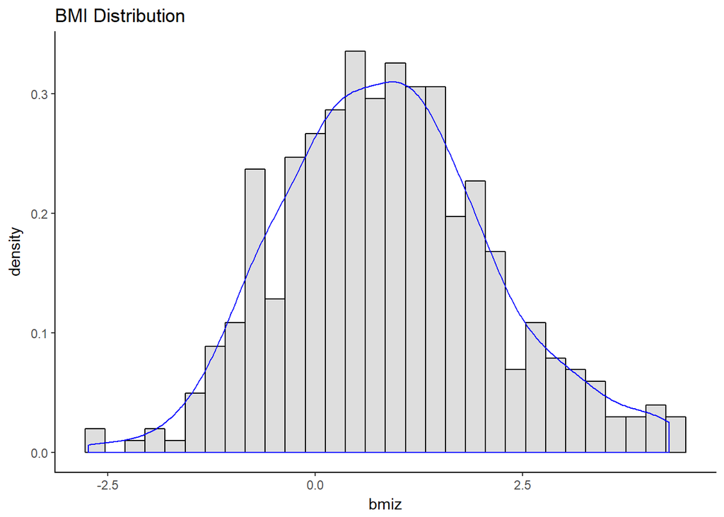

```r
headstartwide %>%
  ggplot(aes(x = bmiz)) +
  geom_histogram(bin = 15, aes(y = ..density..), fill = "grey", color = "black", alpha = 0.5) +
  geom_density(color = "blue") +
  labs( title = "BMI Distribution") + theme
```

### Description

There are 420 subjects in the dataset and 51.7% are female. From the histogram, we can see that the standardized BMI of the sample is right skewed which indicates that there are more overweight children(BMI Z-score > 1.96) than underweight children(BMI Z-score < -1.96) in the sample.

```r
data.frame(count(headstartwide, season_warm), count(headstartwide, sex_female
), count(headstartwide, tv_g2hr), count(headstartwide, video_g1hr), count(headstartwide, mom_work_yes
), count(headstartwide, asthma_yes
), count(headstartwide, mom_born_us
))
```

```
##   season_warm   n sex_female n.1 tv_g2hr n.2 video_g1hr n.3 mom_work_yes
## 1           0 268          0 203       0 212          0 307            0
## 2           1 152          1 217       1 208          1 113            1
##   n.4 asthma_yes n.5 mom_born_us n.6
## 1 226          0 282           0 341
## 2 194          1 138           1  79
```

### Sample Balance

The sample size is quite balanced regarding sex, TV watching and working status of moms, but not very balanced regarding seasons, videogame playing, asthma and whether mother was born in US.

```r
meter =
  meter %>%
  select(., -c(epoch_1:epoch_36)) %>%
  gather(., key = epoch, value = activity, epoch_37:epoch_144) %>%
  mutate(., epoch = as.numeric(gsub("[^\\d]+", "", epoch, perl = TRUE)))
```

```r
headstart =
  left_join(covar, meter, by = "id")
```

## Aggregate Analysis

```r
total_act =
  data.frame(aggregate(headstart$activity, by = list(headstart$id), sum))
colnames(total_act) =  c("id", "total_activity")
total_act =
  left_join(total_act, headstartwide)
```

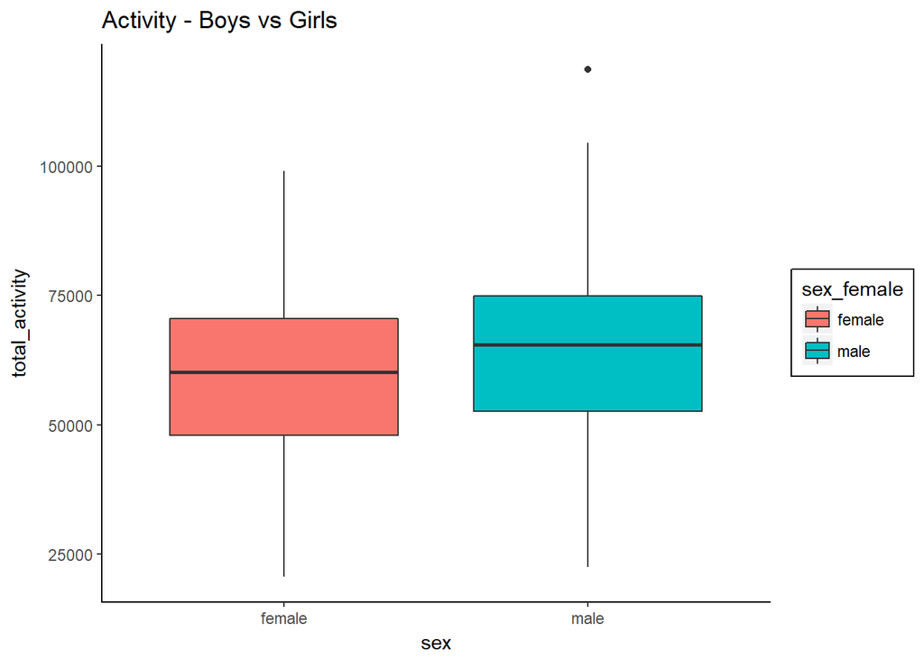

```r
total_act %>%
  mutate(sex_female = ifelse (sex_female == 1, "female", "male"))%>%
  ggplot(aes(x = sex_female,y = total_activity,group = sex_female, fill = sex_female)) +
  geom_boxplot() +
  labs(x = "sex", title = "Activity - Boys vs Girls") + theme
```

```r
t.test(total_activity ~ sex_female, data = total_act)
```

```
##
##  Welch Two Sample t-test
##
## data:  total_activity by sex_female
## t = 3.6513, df = 414.19, p-value = 0.0002944
## alternative hypothesis: true difference in means is not equal to 0
## 95 percent confidence interval:
##  2716.855 9053.647
## sample estimates:
## mean in group 0 mean in group 1
##        65209.79        59324.54
```

### Comment

From the boxplot, we could tell that overally boys are more active than girls. From two sample t-test, the p value is less than 0.001, which indicates that there’s significant difference between total activity of boys and girls.

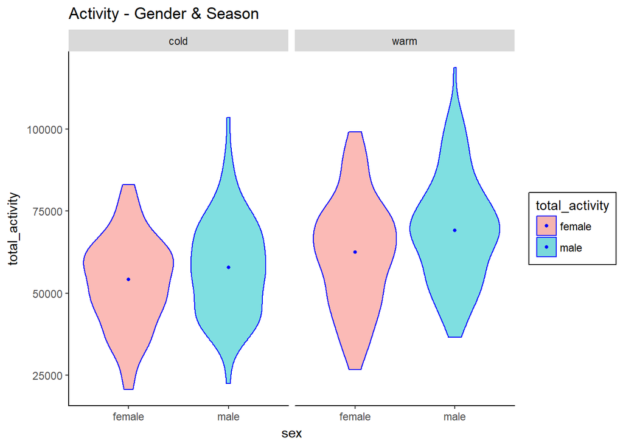

```r
total_act %>%
  mutate(sex_female = ifelse (sex_female == 1, "female", "male"),
         season_warm = ifelse(season_warm == 1, "cold", "warm"))%>%
ggplot(aes(x = sex_female, y = total_activity, fill =  total_activity, )) +
  facet_grid(. ~ season_warm) +
  geom_violin(aes(fill = sex_female), color = "blue", alpha = .5) +
  stat_summary(fun.y = median, geom = "point", color = "blue", size = 1)+
  labs(x = "sex", title = "Activity - Gender & Season") + theme
```

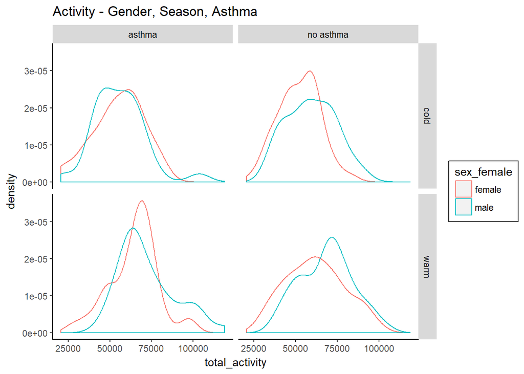

```r
total_act %>%
        mutate(sex_female = ifelse (sex_female == 1, "female", "male"),
         season_warm = ifelse(season_warm == 1, "cold", "warm"),
         mom_work_yes = ifelse(mom_work_yes == 1, "work", "home"),
         asthma_yes = ifelse(asthma_yes == 1, "asthma", "no asthma")) %>%
  ggplot(aes(x = total_activity, group = sex_female)) +
  geom_density(aes(color = sex_female)) +
  facet_grid(season_warm  ~ asthma_yes) +
  labs(title = "Activity - Gender, Season, Asthma") + theme
```

From the density plot, we find that among children with asthma, boys have less activity than girls. Among children with no asthma, boys have more activity than girls.

### Asthma - Activity?

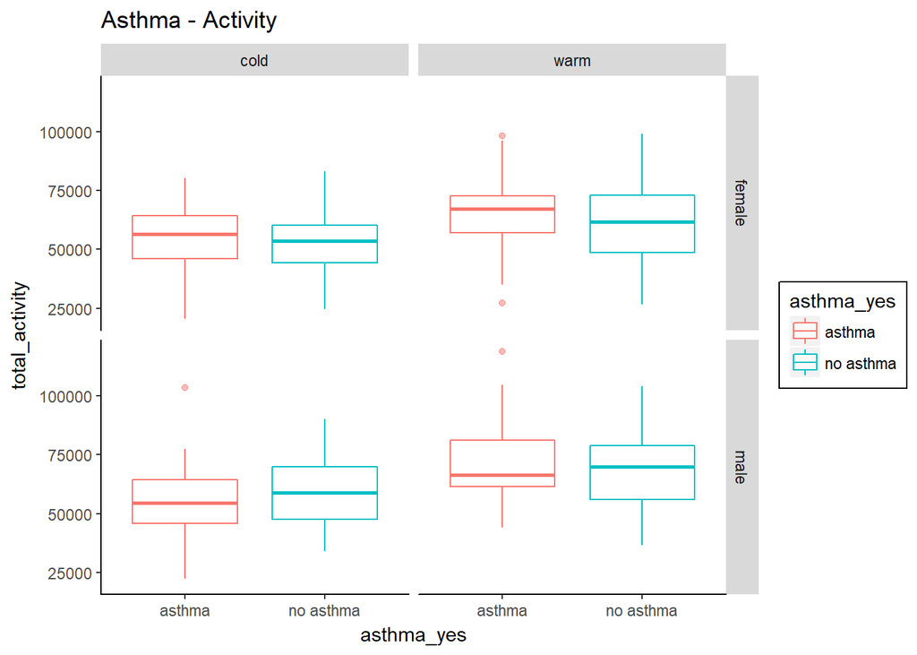

```r
total_act %>%
        mutate(sex_female = ifelse (sex_female == 1, "female", "male"),
         season_warm = ifelse(season_warm == 1, "cold", "warm"),
         asthma_yes = ifelse(asthma_yes == 1, "asthma", "no asthma"))%>%
  ggplot(aes(x = asthma_yes, y = total_activity)) +
    geom_boxplot(aes(color = asthma_yes), alpha = .5) +
  facet_grid(sex_female ~ season_warm)+
  labs(title = "Asthma - Activity") + theme
```

Among girls, those who have asthma tend to have higher levels of total activity. Among boys, the activity difference of asthma group and non-asthma group is not very clear.

### Asthma - BMI?

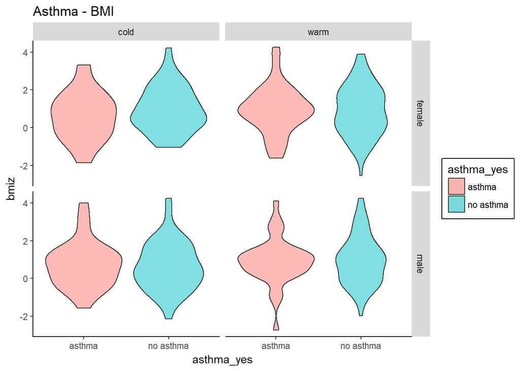

```r
total_act %>%
        mutate(sex_female = ifelse (sex_female == 1, "female", "male"),
         season_warm = ifelse(season_warm == 1, "cold", "warm"),
         asthma_yes = ifelse(asthma_yes == 1, "asthma", "no asthma"))%>%
  ggplot(aes(x = asthma_yes, y = bmiz)) +
    geom_violin(aes( fill = asthma_yes), alpha = .5) +
  facet_grid(sex_female ~ season_warm)+
  labs(title = "Asthma - BMI") + theme
```

The BMI distribution in different groups tend to be different. Generally, people with asthma have a more concentrated BMI distribution than people without asthma.

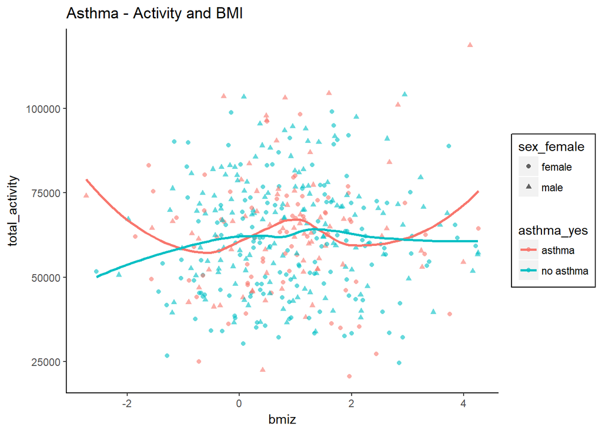

```r
total_act %>%
        mutate(sex_female = ifelse (sex_female == 1, "female", "male"),
         season_warm = ifelse(season_warm == 1, "cold", "warm"),
         asthma_yes = ifelse(asthma_yes == 1, "asthma", "no asthma"))%>%
  ggplot(aes(x = bmiz, y = total_activity)) +
    geom_point(alpha = 0.6, aes(color = asthma_yes, shape = sex_female)) +
  geom_smooth(se = FALSE, aes( group = asthma_yes, color = asthma_yes))+
  labs(title = "Asthma - Activity and BMI") + theme
```

Surprisingly, among children with asthma, the variability of total activity is larger toward different BMI standard values compared to the variability among children with no asthma.

## Time curve analysis

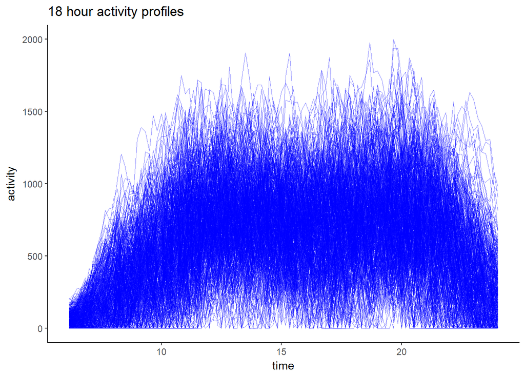

```r
headstart %>%
  mutate(time = epoch/6)%>%
ggplot( aes(x = time, y = activity, group = id)) +
  geom_line(size = 0.01, alpha = 0.5, color = "blue")+
  labs(title = "18 hour activity profiles") + theme
```

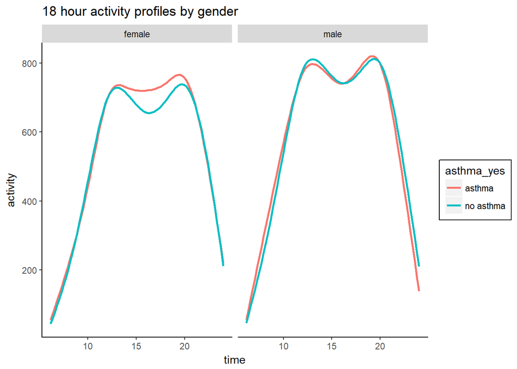

```r
headstart %>%
      mutate(sex_female = ifelse (sex_female == 1, "female", "male"),
         season_warm = ifelse(season_warm == 1, "cold", "warm"),
         mom_work_yes = ifelse(mom_work_yes == 1, "work", "home"),
         tv_g2hr = ifelse(tv_g2hr == 1, "TV", "no TV"),
         video_g1hr = ifelse(video_g1hr == 1, "videogame", "no videogame"),
         mom_born_us = ifelse(mom_born_us == 1, "born US", "not born US"),
         asthma_yes = ifelse(asthma_yes == 1, "asthma", "no asthma"))%>%
  mutate(time = epoch/6)%>%
ggplot( aes(x = time, y = activity, group = id)) +

  facet_grid(. ~ sex_female) +
    geom_smooth(aes(group = asthma_yes, color = asthma_yes), se = FALSE) +
  labs(title = "18 hour activity profiles by gender") + theme
```

Overally, boys with/without asthma have similar activity patterns, wheareas girls with asthma have higher levels of activity than girls without asthma.

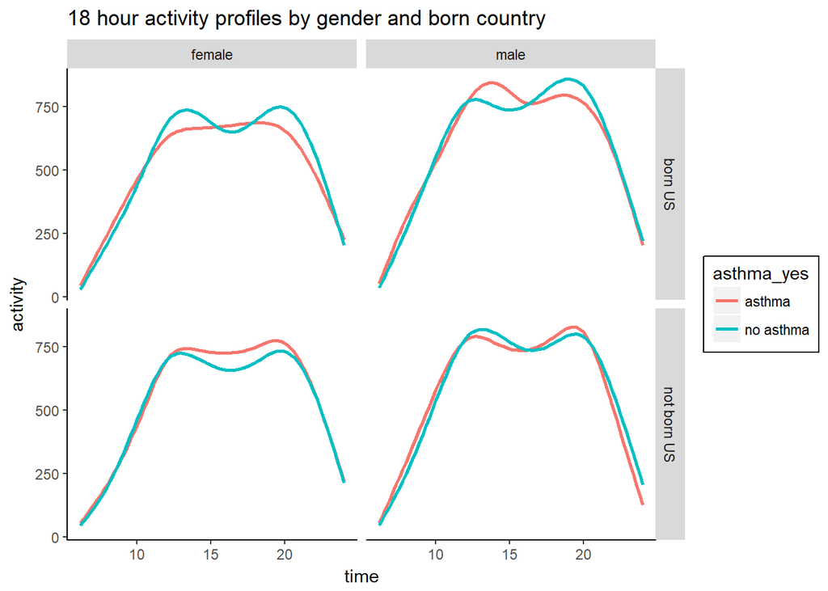

```r
headstart %>%
      mutate(sex_female = ifelse (sex_female == 1, "female", "male"),
         season_warm = ifelse(season_warm == 1, "cold", "warm"),
         mom_work_yes = ifelse(mom_work_yes == 1, "work", "home"),
         tv_g2hr = ifelse(tv_g2hr == 1, "TV", "no TV"),
         video_g1hr = ifelse(video_g1hr == 1, "videogame", "no videogame"),
         mom_born_us = ifelse(mom_born_us == 1, "born US", "not born US"),
         asthma_yes = ifelse(asthma_yes == 1, "asthma", "no asthma"))%>%
  mutate(time = epoch/6)%>%
ggplot( aes(x = time, y = activity, group = id)) +

  facet_grid(mom_born_us ~ sex_female) +
    geom_smooth(aes(group = asthma_yes, color = asthma_yes), se = FALSE) +
  labs(title = "18 hour activity profiles by gender and born country") + theme
```

Looking into the covariates, we find that whether the mother was born in US has an impact on the activity patterns. For example, among girls whose mother born in US, those without asthma have higher levels of activity, which is different with the overall conclusion.

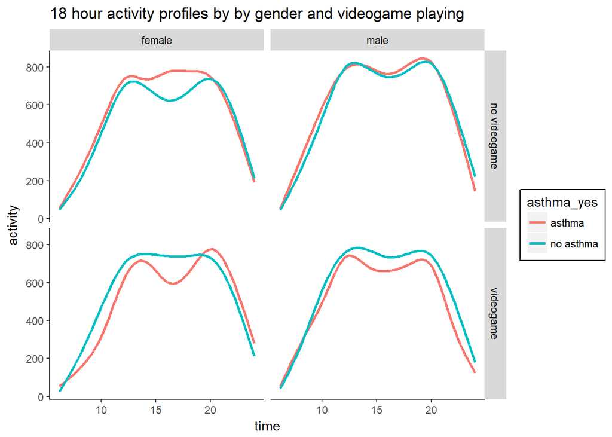

```r
headstart %>%
      mutate(sex_female = ifelse (sex_female == 1, "female", "male"),
         season_warm = ifelse(season_warm == 1, "cold", "warm"),
         mom_work_yes = ifelse(mom_work_yes == 1, "work", "home"),
         tv_g2hr = ifelse(tv_g2hr == 1, "TV", "no TV"),
         video_g1hr = ifelse(video_g1hr == 1, "videogame", "no videogame"),
         mom_born_us = ifelse(mom_born_us == 1, "born US", "not born US"),
         asthma_yes = ifelse(asthma_yes == 1, "asthma", "no asthma"))%>%
  mutate(time = epoch/6)%>%
ggplot( aes(x = time, y = activity, group = id)) +

  facet_grid( video_g1hr ~ sex_female) +
    geom_smooth(aes(group = asthma_yes, color = asthma_yes), se = FALSE) +
  labs(title = "18 hour activity profiles by by gender and videogame playing") + theme
```

The videogame playing group of girls also displays similar discordance with the overall conclusion.

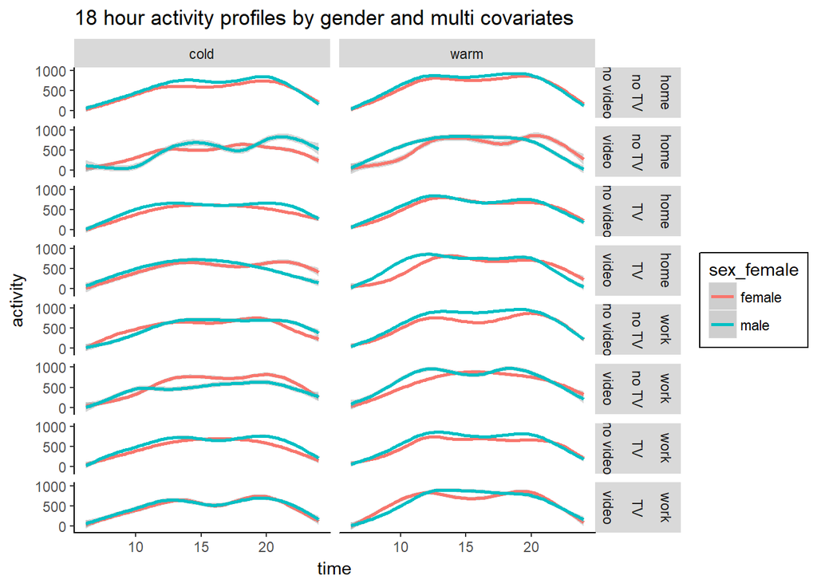

```r
headstart %>%
      mutate(sex_female = ifelse (sex_female == 1, "female", "male"),
         season_warm = ifelse(season_warm == 1, "cold", "warm"),
         mom_work_yes = ifelse(mom_work_yes == 1, "work", "home"),
         tv_g2hr = ifelse(tv_g2hr == 1, "TV", "no TV"),
         video_g1hr = ifelse(video_g1hr == 1, "video", "no video"),
         mom_born_us = ifelse(mom_born_us == 1, "born US", "not born US"),
         asthma_yes = ifelse(asthma_yes == 1, "asthma", "no asthma"))%>%
  mutate(time = epoch/6)%>%
ggplot( aes(x = time, y = activity, group = id)) +

  facet_grid( mom_work_yes ~ tv_g2hr ~ video_g1hr  ~  season_warm) +
    geom_smooth(aes(group = sex_female, color = sex_female)) +
  labs(title = "18 hour activity profiles by gender and multi covariates") + theme +
  scale_y_continuous(breaks = c(0,500,1000))
```

### Comment

In this case, we are really interested in the difference of activity between boys and girls. Overally, boys have higher levels of activity than girls. In some sub-groups, the difference is not very obvious though. For instance, among children whose mother works or studies outside, who watches TV and plays videogames, the activity pattern of boys and girls are almost the same.

The difference of activity between boys and girls is affected by season, whether their mother work or study outside, whether they play videogames and whether they watch TV, etc.